# R Notebook

Looking at ~ 300 new simulations for fake sampe (old simulation) WiTH limit on lifetime (mutations in simulated subtrees are closer to ancestor than the maxdepth of the corresponding sample subtree) New simulations are shifted to the right, and their poisson expectation is even righter (потому что мы запрещаем мутациям садиться далеко, но дерево там все еще продолжается?)

observed median: 93.25 poisson expected median: 91

observed mean: 100.332159624413 poisson expected mean: 98.9619955253928 [1] 95.90727 [1] 103.2909 [1] -7.383636

после исправления бага со стопперами

observed median: 124.5 poisson expected median: 127

observed mean: 128.319956616052 poisson expected mean: 128.552926094138

[1] 130.4391 [1] 135.3655 [1] -4.926396

```r
stats<-read.csv("C:/Users/weidewind/Documents/CMD/Coevolution/Influenza/environment_or_epistasis/newSimCheck/fake_shuffle_limits_exist.txt")
medians <- stats[stats$type == "median",]
mean(medians$obs)
```

```
[1] 130.4391
```

```r
mean(medians$exp)
```

```
[1] 135.3655
```

```r
mean(medians$obs-medians$exp)
```

```
[1] -4.926396
```

Looking at ~ 300 new simulations for fake sampe (old simulation) with NO limits on lifetime Same shit.

observed median: 81.5 poisson expected median: 81

observed mean: 93.4314159292035 poisson expected mean: 93.7936825981911 [1] 82.19195 [1] 91.19814 [1] -9.006192

No limits после исправления бага со стопперами observed median: 79.25

poisson expected median: 79

observed mean: 98.1741245136187

poisson expected mean: 97.2633883454577

1] 81.36585 [1] 85.95122 <- yep: расхождение ожидаемого и наблюдаемого в симуляциях стало меньше (раньше пуассон уходил вправо за стопперы). Но оно все равно слишком большое! [1] -4.585366

```r
stats<-read.csv("C:/Users/weidewind/Documents/CMD/Coevolution/Influenza/environment_or_epistasis/newSimCheck/fake_shuffle_no_limits.txt")
medians <- stats[stats$type == "median",]
mean(medians$obs)
```

```
[1] 81.36585
```

```r
mean(medians$exp)
```

```
[1] 85.95122
```

```r
mean(medians$obs-medians$exp)
```

```
[1] -4.585366
```

Когда ограничение на время жизни есть, максимальная глубина в симуляциях все равно бывает больше, чем в сэмпле. Где ошибка? А вот где: В shuffle_muts_on_subtree просто нигде нет ограничения на максимальную глубину - только на максимальную глубину мутации

Убрали ограничение, но при maxdepth 50 pvalue env все равно 0 (при других maxdepth все нормально) (100 sim) При этом пуассон от наблюдения в симуляции отличается слабо, как и должно быть, а вот в фейке - сильно!

observed median: 112.75 poisson expected median: 103

observed mean: 116.69918699187 poisson expected mean: 113.727910705643

[1] 125.5465 [1] 123.5814 [1] 1.965116

Нашла баг при определении максимального бина, из-за которого концевые бины в итерациях иногда отрезались

observed median: 112.75 poisson expected median: 103

observed mean: 116.69918699187 poisson expected mean: 113.727910705643

[1] 125.8023 [1] 123.814 [1] 1.988372

```r
stats<-read.csv("C:/Users/weidewind/Documents/CMD/Coevolution/Influenza/environment_or_epistasis/newSimCheck/fake_shuffle_no_limits_debugged.txt")
medians <- stats[stats$type == "median",]
mean(medians$obs)
```

```
[1] 125.8023
```

```r
mean(medians$exp)
```

```
[1] 123.814
```

```r
mean(medians$obs-medians$exp)
```

```
[1] 1.988372
```

Вероятно: для короткоживущих поддеревьев в симуляциях часто появляются длинные поддеревья. В коротких длинные начальные ветки занимают больше места, и потому расхождение между набл и ожидаемым по пуассону больше, чем в длинных

.. ии я не вижу никакой связи между глубиной поддерева (или даже разницей между глубинами в фейке и в симуляциях) и p-value

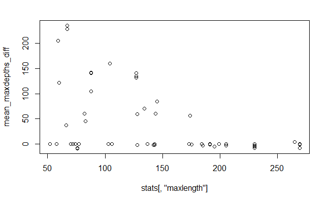

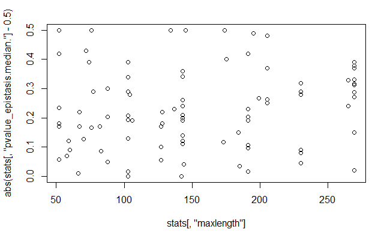

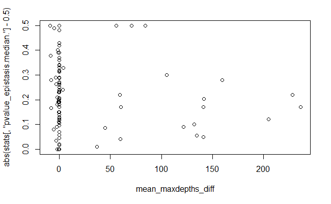

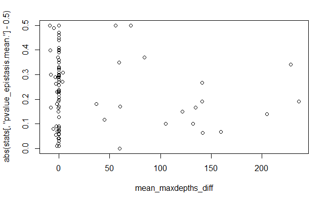

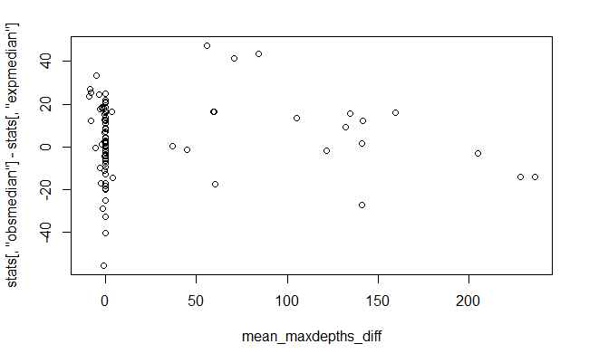

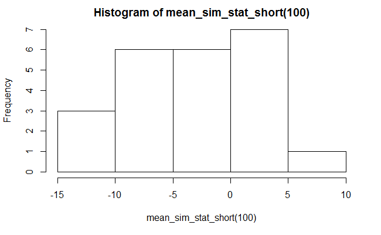

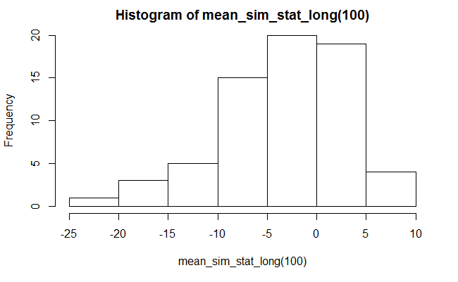

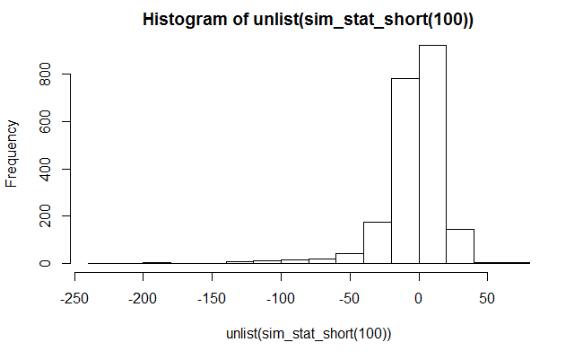

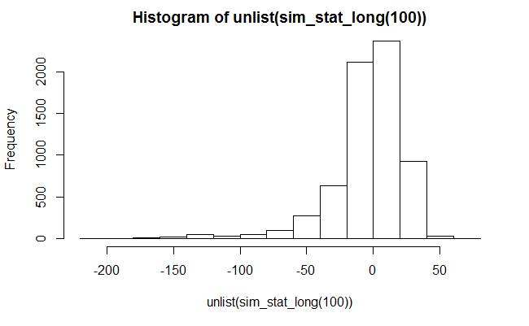

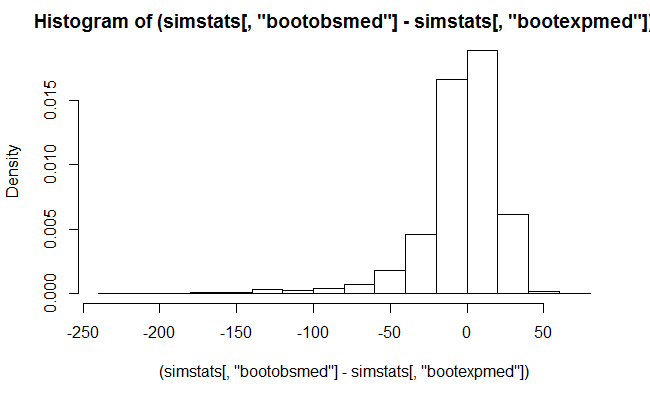

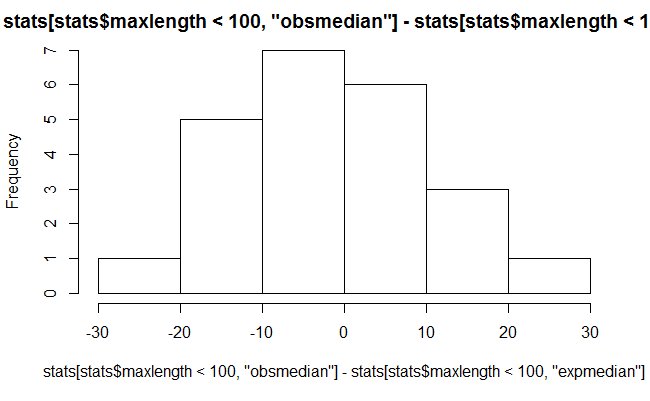

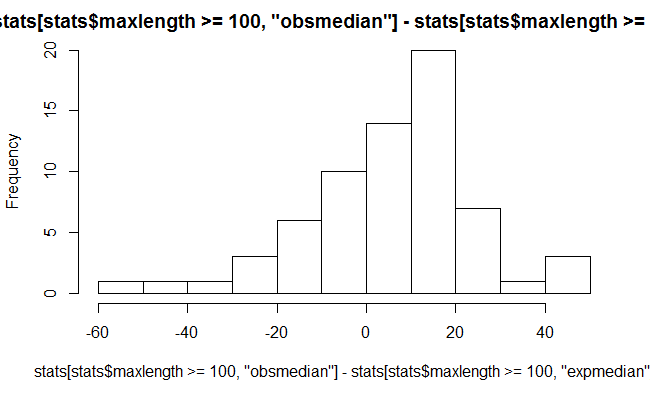

[9 more figures not shown]

```r
stats<-read.csv("C:/Users/weidewind/Documents/CMD/Coevolution/Influenza/environment_or_epistasis/newSimCheck/h1_sites_with_stats")
simstats<-read.csv("C:/Users/weidewind/Documents/CMD/Coevolution/Influenza/environment_or_epistasis/newSimCheck/h1_sim_sites_with_stats")
all_graphs <- function (stats, simstats){
    mean_maxdepths_diff <- sapply (stats$site_node, function(e){
      sims <- simstats[simstats$site_node == e,]
      diff<-  mean(sims$maxdepth) - stats[stats$site_node == e, "maxlength"] # nothing changes when we take max instead of mean
      if(abs(diff) > 3){
       # print (c(diff, stats[stats$site_node == e, "pvalue_epistasis.median."], stats[stats$site_node == e, "obsmedian"]-stats[stats$site_node == e, "expmedian"], #mean(sims$bootobsmed) - mean(sims$bootexpmed)))
      }
      diff

    })
    #mean_maxdepths_diff
    plot(stats[, "maxlength"], mean_maxdepths_diff)
    plot(stats[, "maxlength"], abs(stats[, "pvalue_epistasis.median."]-0.5))
    plot(mean_maxdepths_diff, abs(stats[, "pvalue_epistasis.median."]-0.5))
    plot(mean_maxdepths_diff, abs(stats[, "pvalue_epistasis.mean."]-0.5))
    plot(mean_maxdepths_diff, stats[, "obsmedian"]-stats[, "expmedian"])


    mean_sim_stat_short <- function(maxdepth) {

        sapply (stats[stats$maxlength < maxdepth, "site_node"], function(e){
          sims <- simstats[simstats$site_node == e,]
          diff<-  mean(sims$bootobsmed - sims$bootexpmed) # nothing changes when we take max instead of mean

      })
    }

    mean_sim_stat_long <- function(maxdepth) {

        sapply (stats[stats$maxlength >= maxdepth, "site_node"], function(e){
          sims <- simstats[simstats$site_node == e,]
          diff<-  mean(sims$bootobsmed - sims$bootexpmed) # nothing changes when we take max instead of mean

      })
    }


    sim_stat_short <- function(maxdepth) {

        sapply (stats[stats$maxlength < maxdepth, "site_node"], function(e){
          sims <- simstats[simstats$site_node == e,]
          diff<-  sims$bootobsmed - sims$bootexpmed # nothing changes when we take max instead of mean

      })
    }

    sim_stat_long <- function(maxdepth) {

        sapply (stats[stats$maxlength >= maxdepth, "site_node"], function(e){
          sims <- simstats[simstats$site_node == e,]
          diff<-  sims$bootobsmed - sims$bootexpmed # nothing changes when we take max instead of mean

      })
    }



    p1 <- hist(mean_sim_stat_short(100))
    p2 <- hist(mean_sim_stat_long(100))
    p1nm <- hist(unlist(sim_stat_short(100)))
    p2nm <- hist(unlist(sim_stat_long(100)))
    p0 <- hist((simstats[, "bootobsmed"]-simstats[, "bootexpmed"]), freq = FALSE)





    p3 <- hist(stats[stats$maxlength < 100, "obsmedian"]-stats[stats$maxlength < 100, "expmedian"])
    p4 <- hist(stats[stats$maxlength >= 100, "obsmedian"]-stats[stats$maxlength >= 100, "expmedian"])
    p5 <- hist((stats$obsmedian-stats$expmedian), freq = FALSE)

    plot( p1, col=rgb(0,0,1,1/4), xlim=c(-25,15), ylim = c(0, 20),  freq = FALSE, main = "mean_sim_stat (long and short)")  # first histogram
    plot( p2, col=rgb(1,0,0,1/4), xlim=c(-25,15), ylim = c(0, 20),   freq = FALSE, add=T)  # second

    plot( p3, col=rgb(0,0,1,1/4), xlim=c(-70,70), ylim = c(0, 20), main = "stats (fake) (long and short)",  freq = FALSE)  # first histogram
    plot( p4, col=rgb(1,0,0,1/4), xlim=c(-70,70), ylim = c(0, 20),  freq = FALSE,add=T)  # second

    #plot( p1, col=rgb(0,0,1,1/4), xlim=c(-70,70), ylim = c(0, 20), main = "short (fake and sim mean)")  # first histogram
    #plot( p3, col=rgb(1,0,0,1/4), xlim=c(-70,70), ylim = c(0, 20), add=T)  # second


    #plot( p2, col=rgb(0,0,1,1/4), xlim=c(-70,70), ylim = c(0, 20), main = "long (fake and sim mean)")  # first histogram
    #plot( p4, col=rgb(1,0,0,1/4), xlim=c(-70,70), ylim = c(0, 20), add=T)  # second


    plot( p1nm, col=rgb(0,0,1,1/4), xlim=c(-70,70), ylim = c(0, 0.05),  freq = FALSE, main = "short (fake and sim)")  # first histogram
    plot( p3, col=rgb(1,0,0,1/4), xlim=c(-70,70), ylim = c(0, 0.05), freq = FALSE, add=T)  # second


    plot( p2nm, col=rgb(0,0,1,1/4), xlim=c(-70,70), ylim = c(0, 0.03),  freq = FALSE, main = "long (fake and sim)")  # first histogram
    plot( p4, col=rgb(1,0,0,1/4), xlim=c(-70,70), ylim = c(0, 0.03),freq = FALSE, add=T)  # second

    plot( p0, col=rgb(0,0,1,1/4), xlim=c(-150,150), freq = FALSE, ylim = c(0, 0.03), main = "all" )  # first histogram
    plot( p5, col=rgb(1,0,0,1/4), xlim=c(-150,150), freq = FALSE,  ylim = c(0, 0.03), add=T)  # second

    lsim <- hist(simstats$maxdepth)
    lfake <- hist(stats$maxlength)
    plot( lsim, col=rgb(0,0,1,1/4), xlim=c(0,350), freq = FALSE, ylim = c(0, 0.01), main = "maxdepths" )  # first histogram
    plot( lfake, col=rgb(1,0,0,1/4), xlim=c(0,350), freq = FALSE,  ylim = c(0, 0.01), add=T)  # second
}
graphs <- function (stats, simstats){
    lsim <- hist(simstats$maxdepth)
    lfake <- hist(stats$maxlength)
    plot( lsim, col=rgb(0,0,1,1/4), xlim=c(0,350), freq = FALSE, ylim = c(0, 0.01), main = "maxdepths" )  # first histogram
    plot( lfake, col=rgb(1,0,0,1/4), xlim=c(0,350), freq = FALSE,  ylim = c(0, 0.01), add=T)  # second
    hist(stats[stats$mutations <=3, "pvalue_epistasis.mean."])
    hist(stats[stats$mutations >3, "pvalue_epistasis.mean."])
    plot(stats$pvalue_epistasis.median., stats$pvalue_epistasis.mean.)
    hist(stats$pvalue_epistasis.median)
    hist(stats$pvalue_epistasis.mean)
}
all_graphs(stats, simstats)
```

All: Распределение S для симуляций - левее, чем для фейка (фейк, правда, всего один). Связано ли это с длинами? посмотреть на тотальные распределения длин. Да, они тоже сдвинуты (maxdepth): в фейке длины в среднем больше

Ввели ограничение: в симуляциях запрещаем мутациям ложиться дальше, чем в наблюдении, а при подсчете площадей в симуляциях (subtree_entrenchment) не учитываем те ветки, которые простираются дальше этого ограничения

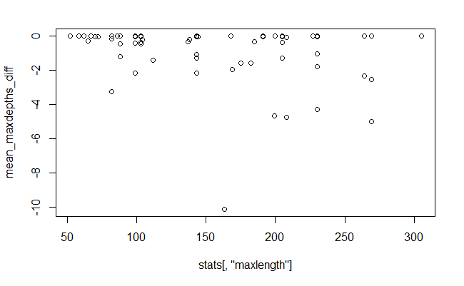

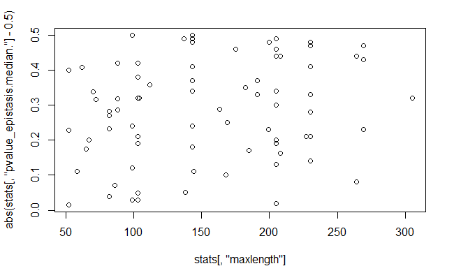

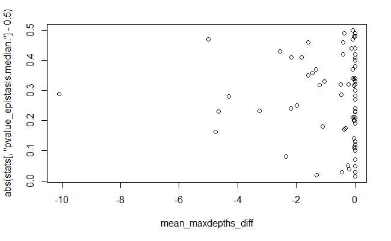

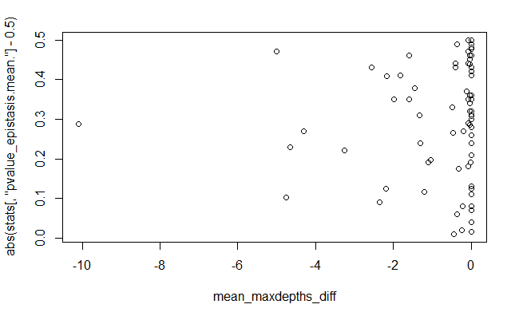

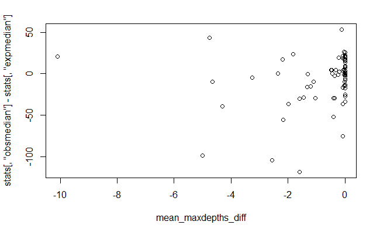

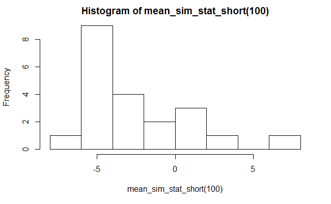

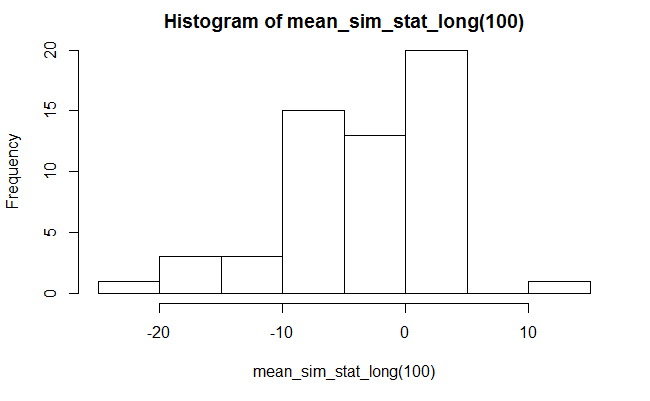

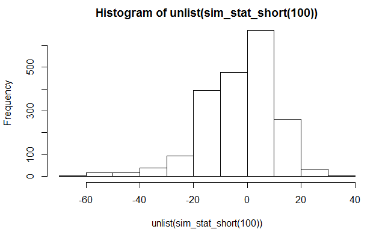

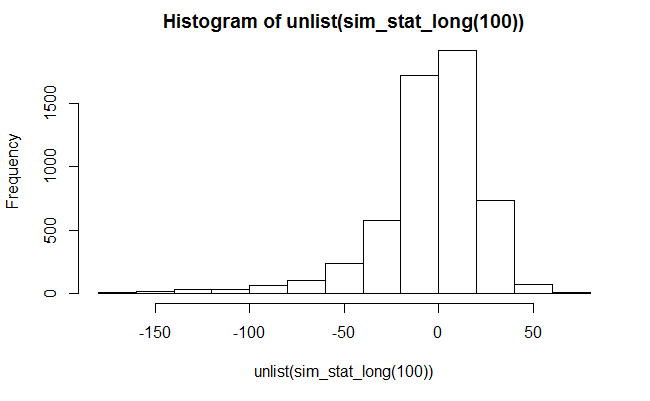

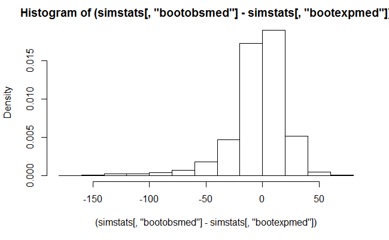

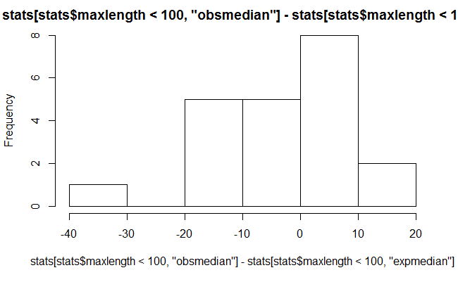

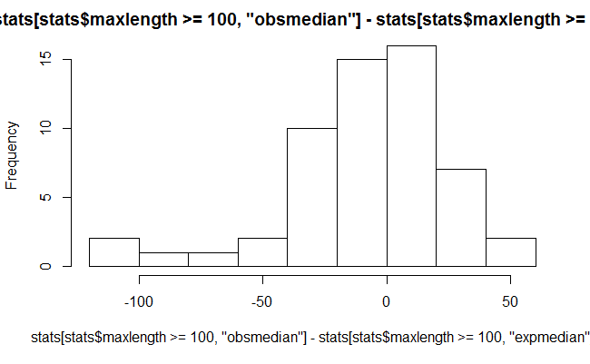

[9 more figures not shown]

```r
stats<-read.csv("C:/Users/weidewind/Documents/CMD/Coevolution/Influenza/environment_or_epistasis/newSimCheck/h1_sites_with_stats_restriction_2")
simstats<-read.csv("C:/Users/weidewind/Documents/CMD/Coevolution/Influenza/environment_or_epistasis/newSimCheck/h1_sim_sites_with_stats_restriction_2")
all_graphs(stats, simstats)
```

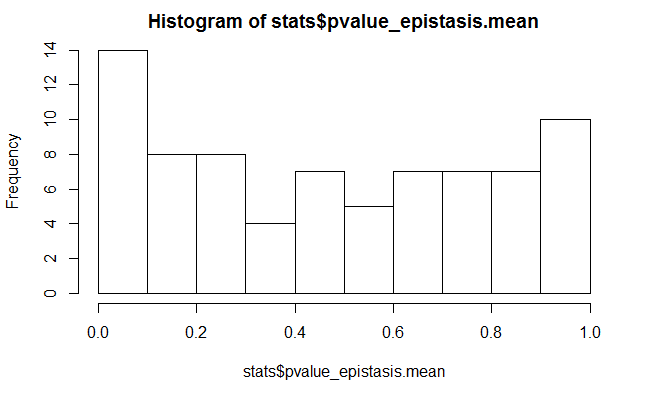

```r
hist(stats$pvalue_epistasis.mean)
```

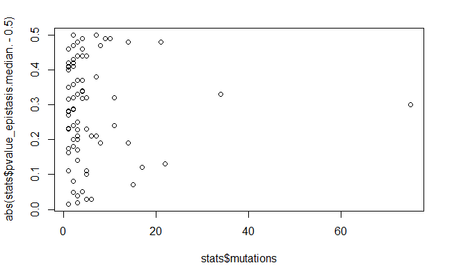

```r
plot(stats$mutations, abs(stats$pvalue_epistasis.median.-0.5))
```

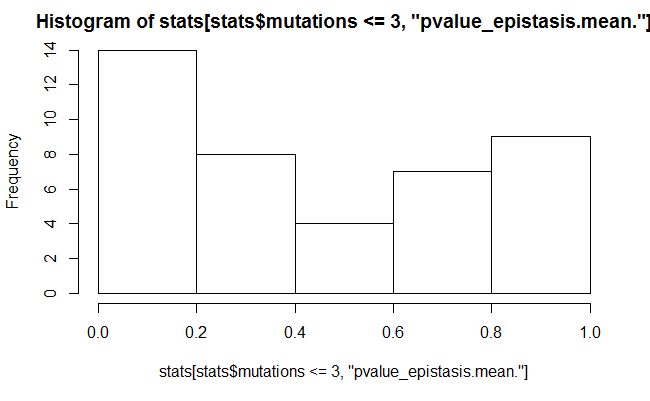

```r
hist(stats[stats$mutations <=3, "pvalue_epistasis.mean."])
```

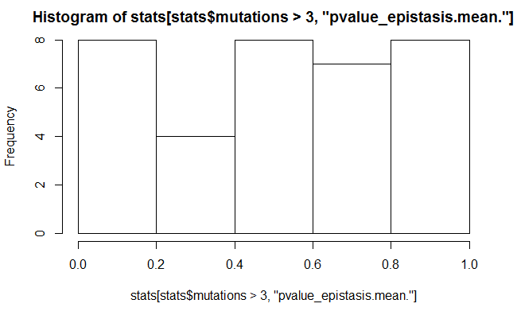

```r
hist(stats[stats$mutations >3, "pvalue_epistasis.mean."])
```

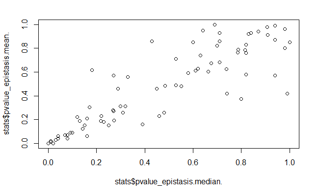

```r
plot(stats$pvalue_epistasis.median., stats$pvalue_epistasis.mean.)
```

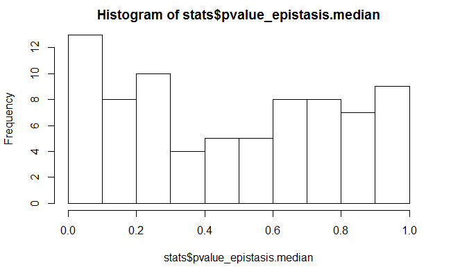

```r
hist(stats$pvalue_epistasis.median)
```

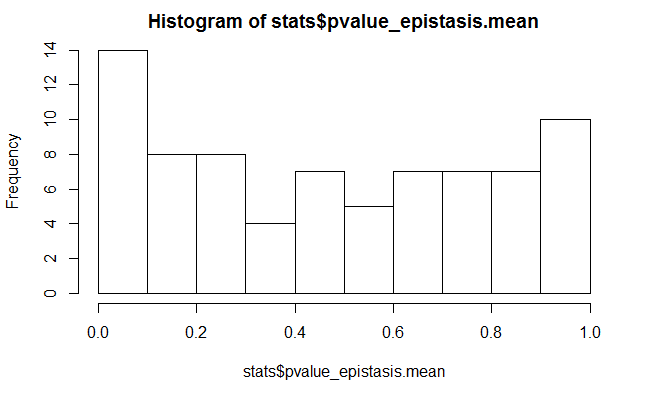

```r
hist(stats$pvalue_epistasis.mean)
```

Теперь посмотрим на большое число фейков одновременно (300 итераций, 100 фейков), на белок целиком pvalues по медиане распределены вменяемо, а по среднему - ужасающе (то ли мы в фейках прижимаемся к корню, то ли в симуляциях уходим далеко на ветки): ситуация перевернулась. Из-за того, что теперь поддеревья в симуляциях всегда короче или равны фейковым?

слабое: если дело в разнице длин поддеревьев, то при ограничении = 150 эффект должен быть менее выражен, чем при 50 (и это действительно так)

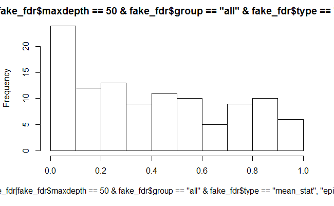

```r
fake_fdr<-read.csv("C:/Users/weidewind/Documents/CMD/Coevolution/Influenza/environment_or_epistasis/newSimCheck/fake_fdr_stats")
hist(fake_fdr[fake_fdr$maxdepth == 50 & fake_fdr$group == "all" & fake_fdr$type == "mean_stat","epi_pvalue"])
```

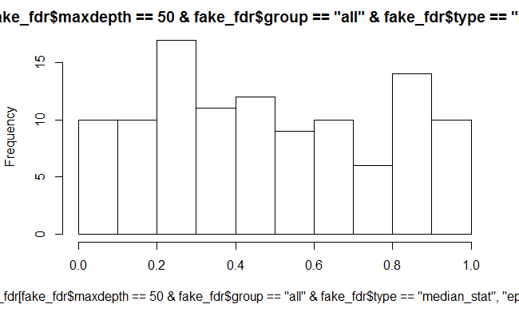

```r
hist(fake_fdr[fake_fdr$maxdepth == 50 & fake_fdr$group == "all" & fake_fdr$type == "median_stat","epi_pvalue"])
```

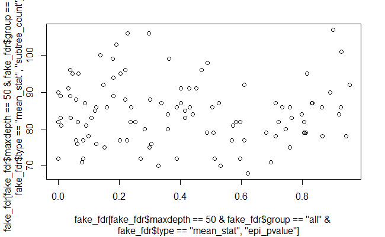

```r
plot(fake_fdr[fake_fdr$maxdepth == 50 & fake_fdr$group == "all" & fake_fdr$type == "mean_stat","epi_pvalue"],fake_fdr[fake_fdr$maxdepth == 50 & fake_fdr$group == "all" & fake_fdr$type == "mean_stat","subtree_count"],)
```

Проверка: взять 2 сета фейков: стареющие и молодеющие, для обоих посмотреть на распределение разностей длин между фейками и соответствующими симуляциями (как в последней гистограмме all_graphs). Если я прав, у молодеющих фейков оно должно быть правее (симуляции коротковаты)

100 фейков, по 300 симуляций для каждого

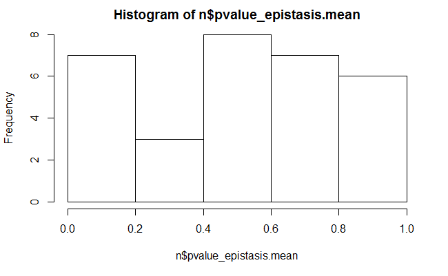

```r
 same_length <- sapply (stats$site_node, function(e){
      sims <- simstats[simstats$site_node == e,]
      diff<-  mean(sims$maxdepth) - stats[stats$site_node == e, "maxlength"] # nothing changes when we take max instead of mean
      if(diff == 0 ){
        e
      }
    })
n <-stats[unlist(same_length),]
hist(n$pvalue_epistasis.mean)
```

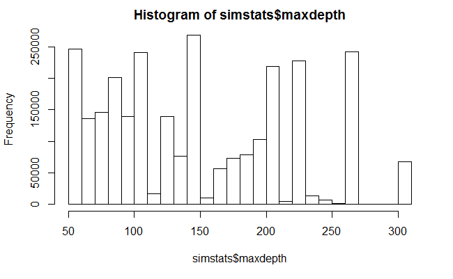

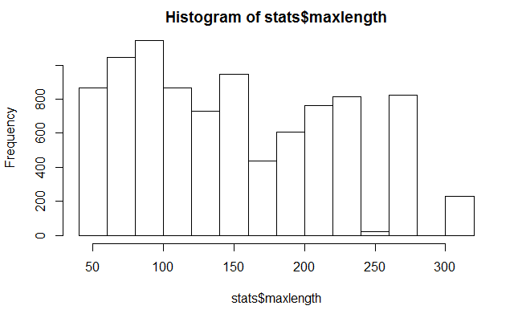

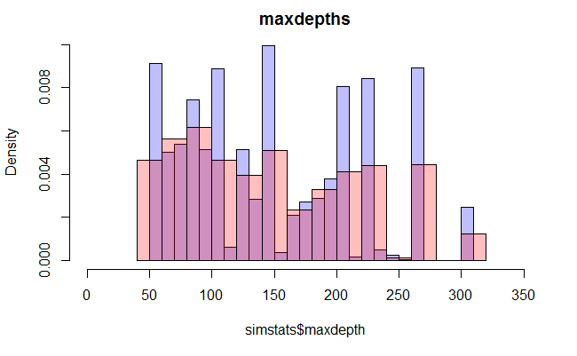

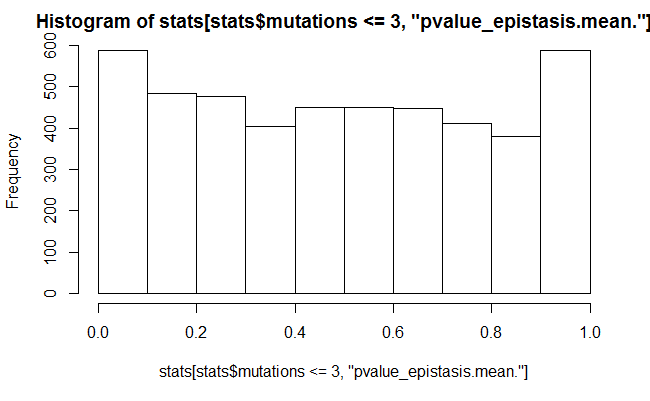

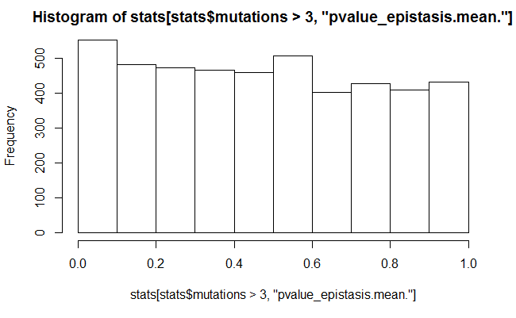

[figure not shown]

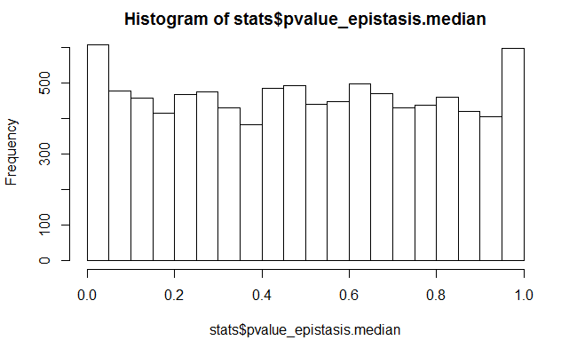

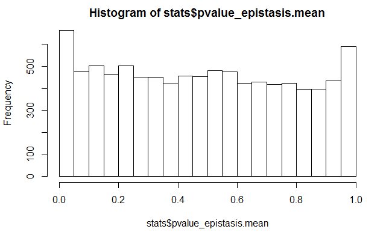

```r
metastats<-read.csv("C:/Users/weidewind/Documents/CMD/Coevolution/Influenza/environment_or_epistasis/newSimCheck/meta_sites_with_stats")
metasimstats<-read.csv("C:/Users/weidewind/Documents/CMD/Coevolution/Influenza/environment_or_epistasis/newSimCheck/meta_sim_sites_with_stats")
graphs(metastats, metasimstats)
```

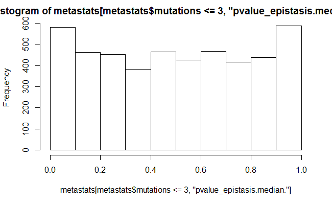

```r
    hist(metastats[metastats$mutations <=3, "pvalue_epistasis.median."])
```

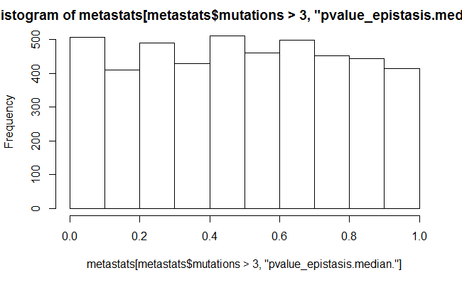

```r
    hist(metastats[metastats$mutations >3, "pvalue_epistasis.median."])
```

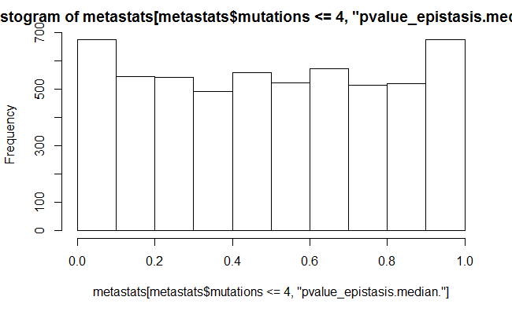

```r
    hist(metastats[metastats$mutations <=4, "pvalue_epistasis.median."])
```

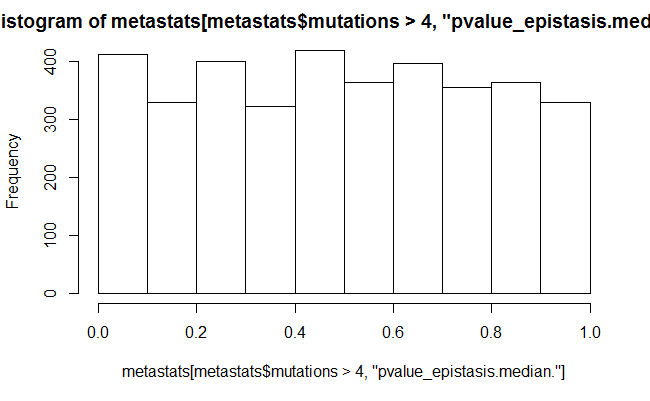

```r
    hist(metastats[metastats$mutations >4, "pvalue_epistasis.median."])
```

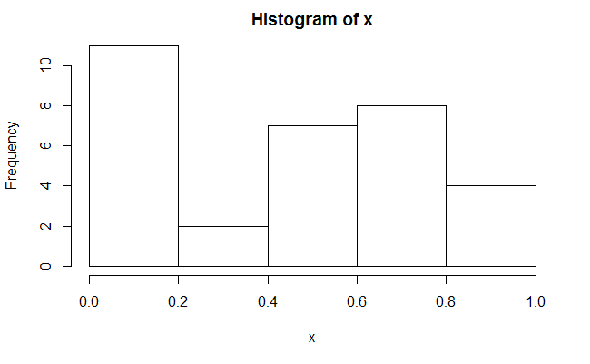

```r
metastats<-read.csv("C:/Users/weidewind/Documents/CMD/Coevolution/Influenza/environment_or_epistasis/newSimCheck/meta_sites_with_stats")
metasimstats<-read.csv("C:/Users/weidewind/Documents/CMD/Coevolution/Influenza/environment_or_epistasis/newSimCheck/meta_sim_sites_with_stats")
x <-c()
for (e in unique(metastats$fakeno)){
  fake <-metastats[metastats$fakeno == e ,]
  simfake <-metasimstats[metasimstats$fakeno == e ,]
  same_length <- sapply (fake$site_node, function(t){
      sims <- simfake[simfake$site_node == t,]
      diff<-  mean(sims$maxdepth) - fake[fake$site_node == t, "maxlength"]
      if(diff == 0 ){
        t
      }
  })
  n <-fake[unlist(same_length),]
  #print(n)
  x<-c(x,n$pvalue_epistasis.mean)
}
#print (x)
hist(x)
```

Исправила баг с серединами веток (изменения от 27.02.2017) (numeric баг еще не исправлен). No lifetime restriction

```r
graphs <- function (stats, simstats){

    lsim <- hist(simstats$maxdepth)
    lfake <- hist(stats$maxlength)
    plot( lsim, col=rgb(0,0,1,1/4), xlim=c(0,350), freq = FALSE, ylim = c(0, 0.01), main = "maxdepths" )  # first histogram
    plot( lfake, col=rgb(1,0,0,1/4), xlim=c(0,350), freq = FALSE,  ylim = c(0, 0.01), add=T)  # second
    hist(stats[stats$mutations <=3, "pvalue_epistasis.median."])
    hist(stats[stats$mutations >3, "pvalue_epistasis.median."])
    hist(stats[stats$mutations <=3, "pvalue_epistasis.mean."])
    hist(stats[stats$mutations >3, "pvalue_epistasis.mean."])
  #  plot(stats$pvalue_epistasis.median., stats$pvalue_epistasis.mean.)
    hist(stats$pvalue_epistasis.median)
    hist(stats$pvalue_epistasis.mean)
}
```